# Análise Exploratória da produção de Leite de Três Vacas em uma fazenda

Autores

joseferson barreto, bacharel em estatística pela úniversidade Estadual da Paraíba

Dr. Thiago Almeida, Universidade Estadual da Paraíba

# Carregando Algumas Bibliotecas

Primeiramente vamos carregar algumas bibliotecas que usaremos em nossas análises.

- A biblioteca **readxl** Wickham e Bryan (2023) para ler o conjunto de dados do excel.
- A biblioteca **dplyr** Wickham et al. (2023) para algumas manipulações no conjunto de dados.
- A biblioteca **knitr** Xie (2023) para manipulações com latex e afins.
- A biblioteca **ggplot2** Wickham (2016) para geração de gráficos.

**Código**

```r
#install.packages("shinythemes")
library(readxl)
library(dplyr)
#getwd()
library(knitr)
```

## Carregando o Banco de Dados

Carregando o banco de dados referente a produção de leite de 3 vacas em uma fazenda

**Código**

```r
#teste<-read.table("C:/Users/joseferson/Documents/joseferson barreto/projeto-final-planejamento2/psubDBC.txt")
 dados <- read_excel("dados.xlsx")
dados<- dados[-1]
 library(knitr)
kable(head(dados, 10))
```

| racao_Comun | Turno | mes | pasta_bovin | soja | rep |
| --- | --- | --- | --- | --- | --- |
| 26 | dia | primeiro mês | 41 | 41 | 1 |
| 26 | tarde | primeiro mês | 41 | 41 | 1 |
| 33 | dia | primeiro mês | 37 | 39 | 1 |
| 25 | tarde | primeiro mês | 40 | 37 | 1 |
| 29 | dia | primeiro mês | 37 | 39 | 1 |
| 34 | tarde | primeiro mês | 36 | 40 | 1 |
| 28 | dia | primeiro mês | 36 | 38 | 1 |
| 27 | tarde | primeiro mês | 40 | 41 | 1 |
| 29 | dia | primeiro mês | 37 | 37 | 1 |
| 32 | tarde | primeiro mês | 39 | 43 | 1 |

**Código**

```r
#==================================================================================
#                      transformando os dados                                    #
#==================================================================================


# Criar a nova variável "dia_mes"
dados <- dados %>%
  group_by(mes) %>%
  mutate(
    dia_mes = rep(paste0("dia ", rep(1:30, each = 2)), length.out = n())
  )

# Visualizar os dados resultantes
#print(dados)



# Criar a nova variável "dia_mes_com_mes"
dados <- dados %>%
  mutate(dia_mes_com_mes = paste(dia_mes, mes, sep = " "))

# Criando vetores vazios para armazenar os dados e a identificação da variável
prod <- c()
variavel <- c()

# Número total de observações e de variáveis
num_observacoes <- 360
variaveis <- c("soja", "pasta_bovin", "racao_Comun")
num_variaveis <- length(variaveis)

# Loop para preencher as variáveis prod e variavel
for (i in 1:(num_observacoes/2)) {
  # Iteração sobre as variáveis
  for (j in 1:num_variaveis) {
    # Adicionando duas observações da variável atual
    prod <- c(prod, dados[[variaveis[j]]][((i - 1) * 2 + 1):(i * 2)])

    # Adicionando a identificação da variável
    variavel <- c(variavel, rep(variaveis[j], 2))
  }
}

# # Verificando os resultados
# head(prod)
# head(variavel)






banco<-data.frame(prod=c(prod),turno=as.factor(c(dados$Turno,
              dados$Turno,dados$Turno)),blocos=as.factor(c(dados$rep,
                  dados$rep,dados$rep))) #, dias = c(dados$dia_mes_com_mes,
                 # dados$dia_mes_com_mes,dados$dia_mes_com_mes))



banco$tipos_rações<-as.factor(c(variavel))



banco$prod<-as.numeric(banco$prod)
```

**Observação**

para mais temas e costomisações confira a documentação da biblioteca **shinythemes** Chang (2021)

## Exibindo o Dataset Final

**Código**

```r
p<-banco |> select(tipos_rações,turno,blocos,prod)
banco <-p
banco1 <- banco

colnames(banco1)<-c("tipo rações","Turno","Bloco", 'prod')

#kable(head(banco1, 10))
```

fonte: Joseferson Barreto

| tipo rações | Turno | Bloco | prod |
| --- | --- | --- | --- |
| soja | dia | 1 | 41 |
| soja | tarde | 1 | 41 |
| pasta_bovin | dia | 1 | 41 |
| pasta_bovin | tarde | 1 | 41 |
| racao_Comun | dia | 1 | 26 |
| racao_Comun | tarde | 1 | 26 |
| soja | dia | 1 | 39 |
| soja | tarde | 1 | 37 |
| pasta_bovin | dia | 1 | 37 |
| pasta_bovin | tarde | 1 | 40 |

## Fazendo a análise exploratória

Vamos fazer a análise exploratória,primeiramente vamos observar osn tipos de variáveis

**Código**

```r
#| label: fig-pressure
#| fig-cap: "Pressure"
#| code-fold: true

# converter  a variável prod para númerica

banco$prod <- as.integer(banco$prod)


banco |> glimpse()
```

```
Rows: 1,080
Columns: 4
$ tipos_rações <fct> soja, soja, pasta_bovin, pasta_bovin, racao_Comun, racao_…
$ turno        <fct> dia, tarde, dia, tarde, dia, tarde, dia, tarde, dia, tard…
$ blocos       <fct> 1, 1, 1, 1, 1, 1, 1, 1, 1, 1, 1, 1, 1, 1, 1, 1, 1, 1, 1, …
$ prod         <int> 41, 41, 41, 41, 26, 26, 39, 37, 37, 40, 33, 25, 39, 40, 3…
```

**Código**

```r
#| label: fig-pressure
#| fig-cap: "Pressure"
#| code-fold: true



# library(ggplot2)
#
# ggplot(data = banco, aes(x = turno,y = tipos_rações)) +
#   geom_bar() +
#   labs(title = "Distribuição da Variável Turno",
#        x = "Turno",
#        y = "Contagem")
#
#
#
# ggplot(data = banco, aes(x = turno, fill = tipos_rações)) +
#   group_by(tipos_rações)+
#   geom_bar(position = "stack") +
#   labs(title = "Distribuição de Turno por Tipos de Rações",
#        x = "Turno",
#        y = "Contagem",
#        fill = "Tipos de Rações")
#
#
#
#
#
#
#
#
# ggplot(data = banco, aes(x = turno, fill = tipos_rações)) +
#   geom_bar(position = "stack") +
#   labs(title = "Distribuição de Turno por Tipos de Rações",
#        x = "Turno",
#        y = "Contagem",
#        fill = "Tipos de Rações")

#install.packages("moments",dependencies = TRUE)
library(moments)

descritiva <- banco %>%
  summarise("Média produção" = sprintf("%.2f", round(mean(prod, na.rm = TRUE), 2)),
            "Mediana produção" = sprintf("%.2f", round(median(prod, na.rm = TRUE), 2)),
            "Assimétria" = sprintf("%.2f", round(skewness(prod, na.rm = TRUE), 2)),
            "Curtose" = sprintf("%.2f", round(kurtosis(prod, na.rm = TRUE), 2)))

#============================================================================
#                   observação
#============================================================================


# A função sprintf("%.2f") formata a saida dos resultados para que os zeros após a virgula sejam exibidos


descritiva |> kable(align = "c")
```

| Média produção | Mediana produção | Assimétria | Curtose |
| --- | --- | --- | --- |
| 24.50 | 28.00 | -0.28 | 1.67 |

### Interpretando os Resultados

- *Média*
  - Logo , podemos afirmar que a média da produção de leite dessas 3 vagas ao longo dos 6 meses foi de 24,50 litros
- *Mediana*
  - A mediana da produção de leite dessas 3 vagas juntas foi de 28 litros ao longo desses 6 meses

*Assimétria*

- Note que o coeficiente de assimétria foi de -0,28 , isso indica que temos uma ,**Assimetria negativa**: A distribuição é inclinada para a esquerda, indicando que há uma dispersão maior de valores menores em relação aos valores maiores.

Exemplos comuns de distribuições assimétricas à esquerda incluem distribuições de tempo de espera em uma fila, distribuições de tempo de vida de produtos.

- *Curtose*
  - o Valor da curtose em nosso conjunto de dados foi de 1,67.

  A Curtose é uma medida estatística que descreve a forma da distribuição de probabilidade de uma variável aleatória. Ela compara a distribuição de uma variável com a distribuição normal padrão. A curtose de uma distribuição normal padrão é definida como 3.

  Se $K >3$ a distribuição é mais “pontiaguda” e “pesada” nas caudas do que uma distribuição normal, e é chamada de leptocúrtica.

  Se $K < 3$ a distribuição é mais “achatada” do que uma distribuição normal, e é chamada de platicúrtica.

  Se $K = 3$ a distribuição é chamada de mesocúrtica e tem a mesma curtose da distribuição normal.

  Logo, podemos afirmar que nossa siatribuição é mais achatada que a distribuição normal, oe seja , ela é platicúrtica.
- *Moda*

A moda é lor que ocorre com mais frequência em uma distribuição de dados. Vamos utilizar o código abaixo para calcular a moda:

**Código**

```r
#| label: fig-pressure
#| fig-cap: "Pressure"
#| code-fold: true



banco |>  select(prod)  %>%

                 table()     %>%

                 which.max () %>%

                 names ()     %>%

                 as.numeric()
```

```
[1] 35
```

Note que a moda foi maior que a média e a mediana ou seja $\text{Moda} > \text{Mediana} > \text{Média}$ isso indica que temos uma Assimétria negátiva como vimos anteriomente .

Logo, com essas características apresentadas pode-se dizer que nossa variável resposta não segue a distribução normal,vamos mostrar em um histograma

**Código**

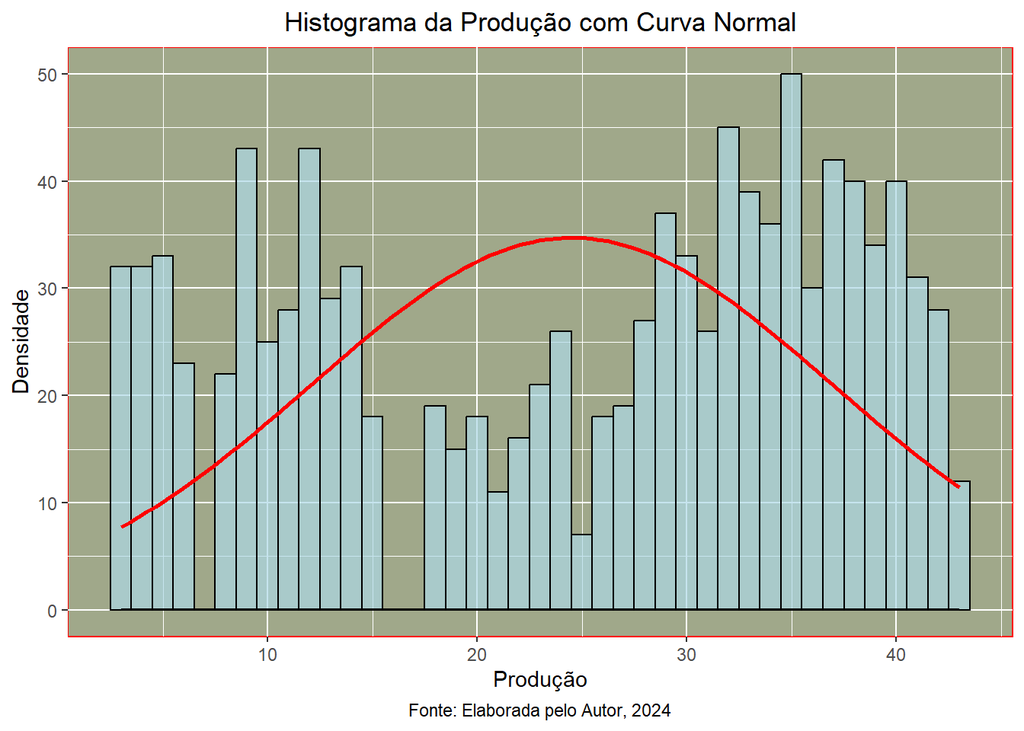

```r
#| label: fig-pressure
#| fig-cap: "Pressure"
#| code-fold: true


#hist(banco$prod)
library(dplyr)
library(ggplot2)

banco_summary <- banco %>%
  group_by(turno, tipos_rações) %>%
  summarize(Contagem = n())

# ggplot(data = banco_summary, aes(x = turno, y = Contagem, fill = tipos_rações)) +
#   geom_histogram(stat = "identity", position = "dodge") +
#   geom_density(aes(color = tipos_rações), size = 1.5) +  # Adiciona a curva da densidade
#   labs(title = "Distribuição de Turno por Tipos de Rações",
#        x = "Turno",
#        y = "Contagem",
#        fill = "Tipos de Rações",
#        color = "Tipos de Rações")  # Adiciona a legenda para a curva da densidade



# Assuming 'produção' is the variable representing production in your dataset

# Load necessary libraries
library(ggplot2)

# # Create a histogram of production with density curve
# ggplot(data = banco, aes(x = prod)) +
#   geom_histogram(binwidth = 1, fill = "lightblue", color = "black", alpha = 0.7) +  # Adjust binwidth and transparency
#   geom_density(alpha = 0.8, fill = "#FF6500") +  # Add density curve with color and transparency
#   labs(title = "Histograma da Produção", x = "Produção", y = "Densidade") +
#   theme_minimal()


# ggplot(data = banco, aes(x = prod))+
#   geom_histogram() +
# geom_density(position = "identity")








# Calculate mean and standard deviation of your data
mean_value <- mean(banco$prod)
sd_value <- sd(banco$prod)
n <- nrow(banco) # Number of observations
lagura <- binwidth <-1  # Assuming you have defined binwidth earlier

autor <- "joseferson Barreto"
ano <-"2024"
# Create a histogram of production with density curve and normal curve
ggplot(data = banco, aes(x = prod)) +
  geom_histogram(binwidth = binwidth, fill = "lightblue", color = "black", alpha = 0.7) +
  geom_density(alpha = 0.3, fill = "#FFA500") +
  stat_function(fun = function(x) dnorm(x, mean = mean_value, sd = sd_value) * n * lagura, color = "red", size = 1) +
  labs(title = "Histograma da Produção com Curva Normal", x = "Produção", y = "Densidade", caption = paste("Fonte: Elaborada pelo Autor,", ano)) +
  theme(panel.background = element_rect(fill='#a0a88a', colour='red'),
        plot.caption = element_text(hjust = 0.5),
        plot.title = element_text(hjust = 0.5))
```

**Código**

```r
#shapiro.test(banco$prod)
```

Como pode-se observar , a distribuição dos nossos dados apresenta um achatamento maior que da distribuição normal, logo , podemos afirmar que a variável **prod** não segue a distruição normal. outra forma de observar isso , é pelo teste de Shapiro Wilk Shapiro e Wilk (1965)

## Teste De Shapiro Wilk

### Hipóteses do teste

$$\begin{cases}
\text{H0:Os erros têm distribuição normal; $\hspace{1,55cm}$ se $\alpha$ > 0,05} \\
\text{H1:Os erros não têm distribuição normal; $\hspace{1cm}$ se $\alpha$ < 0,05}
\end{cases}$$

**Código**

```r
shapiro.test(banco$prod)
```

```
    Shapiro-Wilk normality test

data:  banco$prod
W = 0.9178, p-value < 2.2e-16
```

Como o $P\_{valor} < \alpha = 0,05$ temos que nossa variável não segue a distribuição normal.

## Referências

Chang, Winston. 2021. «shinythemes: Themes for Shiny». https://CRAN.R-project.org/package=shinythemes.

Shapiro, S. S., e M. B. Wilk. 1965. «An analysis of variance test for normality (complete samples)». *Biometrika* 52: 591–611. https://doi.org/10.2307/2333709.

Wickham, Hadley. 2016. «ggplot2: Elegant Graphics for Data Analysis». https://ggplot2.tidyverse.org.

Wickham, Hadley, e Jennifer Bryan. 2023. «readxl: Read Excel Files». https://CRAN.R-project.org/package=readxl.

Wickham, Hadley, Romain François, Lionel Henry, Kirill Müller, e Davis Vaughan. 2023. «dplyr: A Grammar of Data Manipulation». https://CRAN.R-project.org/package=dplyr.

Xie, Yihui. 2023. «knitr: A General-Purpose Package for Dynamic Report Generation in R». https://yihui.org/knitr/.